# Gated Recurrent Neural Networks: Exploration of LSTMs, GRUs, and MGUs

Next, we look at how the models perform over BPTT:

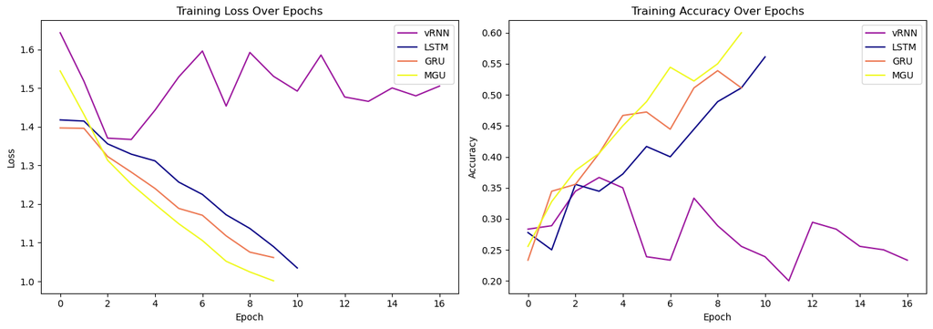

```python
colors = ['#9c179e','#0d0887','#ed7953','#f0f921']

fig, axes = plt.subplots(1, 2, figsize=(14, 5))

for i, history in enumerate(model_history):
    axes[0].plot(history.epoch,
                 history.history['loss'],
                 label=model_labels[i],
                 color=colors[i])
    axes[1].plot(history.epoch,
                 history.history['accuracy'],
                 label=model_labels[i],
                 color=colors[i])

axes[0].set_title('Training Loss Over Epochs')
axes[0].set_xlabel('Epoch')
axes[0].set_ylabel('Loss')
axes[0].legend()


axes[1].set_title('Training Accuracy Over Epochs')
axes[1].set_xlabel('Epoch')
axes[1].set_ylabel('Accuracy')
axes[1].legend()

plt.tight_layout()
plt.show()
```

The vRNN struggles to derease in error or increase in accuracy throughout the duration of 16 epochs. However, each gRNN is able to steadily decrease in error and relatively steadily increase in accuracy and terminates in 10 or under epochs.

This showcases two things. One, gRNNs are able to steadily decrease the loss function by effectively changing their weights according to BPTT, while vRNN struggles to make any notable improvements. This is likely due to the vanishing gradients problem: with so many time steps, vRNN’s gradients get so small that it struggles to make notable parameter improvements from epoch to epoch. Hence, gRNNs architecture is able to mitigate the effects of the vanishing gradients.

Secondly, by mitigating these effects, gRNNs likely also uitilize more information by being able to learn throughout all timepoints. This extra information allows it to learn quicker and terminate sooner than vRNNs, while also more effectively increase in accuracy.

Finally, we take a look at how each model performs on the test data:

```python
accuracies = []
conf_matrices = []

for label, model in zip(model_labels, models):
    y_preds_proba = model.predict(X_test, verbose=0)
    y_preds = np.argmax(y_preds_proba, axis=1)

    acc = accuracy_score(y_test, y_preds)
    cm = confusion_matrix(y_test, y_preds)

    accuracies.append(acc)
    conf_matrices.append(cm)
```

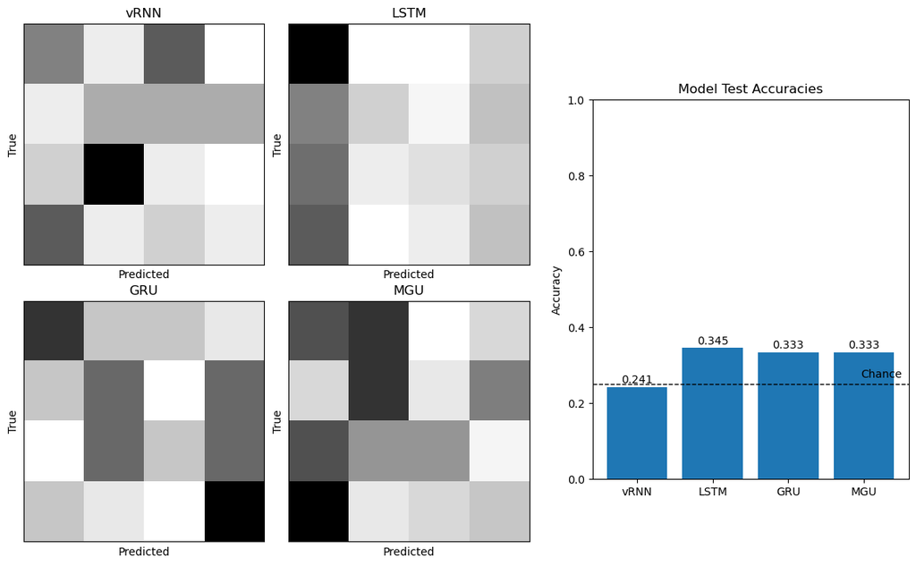

```python
fig = plt.figure(figsize=(16, 8))

left_grid = fig.add_gridspec(
    2, 2,
    left=0.1,
    right=0.5,
    top=0.92,
    bottom=0.10,
    wspace=0.1,
    hspace=0.15
)

for idx, (cm, label) in enumerate(zip(conf_matrices, model_labels)):
    ax = fig.add_subplot(left_grid[idx // 2, idx % 2])

    im = ax.imshow(cm, cmap='Greys')

    ax.set_title(label)
    ax.set_xlabel("Predicted")
    ax.set_ylabel("True")

    ax.set_xticks([])
    ax.set_yticks([])

ax_bar = fig.add_axes([0.55, 0.20, 0.25, 0.60])

bars = ax_bar.bar(model_labels, accuracies)

ax_bar.set_ylabel("Accuracy")
ax_bar.set_ylim(0, 1)
ax_bar.set_title("Model Test Accuracies")

ax_bar.axhline(
    y=0.25,
    color='black',
    linestyle='--',
    linewidth=1
)

ax_bar.text(
    len(model_labels) - 0.5,
    0.26,
    "Chance",
    ha='right',
    va='bottom'
)

for i, acc in enumerate(accuracies):
    ax_bar.text(i, acc + 0.01, f"{acc:.3f}", ha='center')

plt.show()
```

Again, we note that this data is complicated, so it is not surprising that the test accuracy is much lower. Each of the models are likely acceptable to overfitting from so many weight updates through time, and since the data size is so small. However, of note is that since there are 4 classes, an accuracy of 0.25 signifies classification via chance. The vRNN just misses this threshold, while each gRNN is able to surpass it. Thus, while its numerical improvement on the test data is much smaller than the training data, its effective improvement is extremely powerful compared to the vRNN.

It is also worth noting the comparable accuracy and efficiency of each gRNN. One model does not seem to vastly outperform the other in any metric, except notably time, in which the MGU surpasses that of the LSTM and GRU. Therefore, while the performance is likely dependent on the scenario, it is worth noting that this shows the MGU may be more efficient at using the gating architecture to achieve better performance. It also highlights the original claim from the authors of the MGU [8], which is that the forget gate, or the gate that controls what information is added to each hidden state, is likely the most important one.

## References

[1] K. Cho et al., “Learning Phrase Representations using RNN Encoder–Decoder for Statistical Machine Translation,” in Proceedings of the 2014 Conference on Empirical Methods in Natural Language Processing (EMNLP), A. Moschitti, B. Pang, and W. Daelemans, Eds., Doha, Qatar: Association for Computational Linguistics, Oct. 2014, pp. 1724–1734. doi: 10.3115/v1/D14-1179.

[2] K. Greff, R. K. Srivastava, J. Koutník, B. R. Steunebrink, and J. Schmidhuber, “LSTM: A Search Space Odyssey,” IEEE Transactions on Neural Networks and Learning Systems, vol. 28, no. 10, pp. 2222–2232, Oct. 2017, doi: 10.1109/TNNLS.2016.2582924.

[3] S. Hochreiter and J. Schmidhuber, “Long Short-Term Memory,” Neural Comput., vol. 9, no. 8, pp. 1735–1780, Nov. 1997, doi: 10.1162/neco.1997.9.8.1735.

[4] José C. García Alanis, “Introduction to EEG-preprocessing.” Accessed: Jun. 10, 2026. [Online]. Available: https://g0rella.github.io/gorella_mwn/preprocessing_eeg.html#now-that-the-raw-file-has-been-created-we-can-plot-the-data

[5] R. Leeb, F. Lee, C. Keinrath, R. Scherer, H. Bischof, and G. Pfurtscheller, “Brain–Computer Communication: Motivation, Aim, and Impact of Exploring a Virtual Apartment,” IEEE Transactions on Neural Systems and Rehabilitation Engineering, vol. 15, no. 4, pp. 473–482, Dec. 2007, doi: 10.1109/TNSRE.2007.906956.

[6] Michael C. Mozer, “A Focused Backpropagation Algorithm for Temporal Pattern Recognition | Request PDF.” Accessed: Jun. 10, 2026. [Online]. Available: https://www.researchgate.net/publication/243781476_A_Focused_Backpropagation_Algorithm_for_Temporal_Pattern_Recognition

[7] K. B. Petersen and M. S. Pedersen, [ http://matrixcookbook.com ], Version 20121115. Technical University of Denmark, 2012.

[8] G.-B. Zhou, J. Wu, C.-L. Zhang, and Z.-H. Zhou, “Minimal gated unit for recurrent neural networks,” Int. J. Autom. Comput., vol. 13, no. 3, pp. 226–234, Jun. 2016, doi: 10.1007/s11633-016-1006-2.